# Purchased bikes classification

Alex Araya-Lobo

Last edited 18 marzo 2021

The `bikes` dataset provides information about purchased bikes and characteristics about their buyers. Source: [Kaggle](https://www.kaggle.com/heeraldedhia/bike-buyers)

[figure not shown]

```r
bikes <- read_csv("bike_buyers_clean.csv")
head(bikes)
```

```
## # A tibble: 6 x 13
##      ID `Marital Status` Gender Income Children Education       Occupation
##   <dbl> <chr>            <chr>   <dbl>    <dbl> <chr>           <chr>
## 1 12496 Married          Female  40000        1 Bachelors       Skilled Manual
## 2 24107 Married          Male    30000        3 Partial College Clerical
## 3 14177 Married          Male    80000        5 Partial College Professional
## 4 24381 Single           Male    70000        0 Bachelors       Professional
## 5 25597 Single           Male    30000        0 Bachelors       Clerical
## 6 13507 Married          Female  10000        2 Partial College Manual
## # ... with 6 more variables: Home Owner <chr>, Cars <dbl>,
## #   Commute Distance <chr>, Region <chr>, Age <dbl>, Purchased Bike <chr>
```

#### **Explore data**

```r
#Rename variables
bikes <-
  bikes %>%
    rename_all(function(.name) {
      .name %>%
        tolower %>%
      str_replace(" ", "_") # replace all spaces with underscores
    }) %>% select(-id) %>% mutate_if(is.character, as.factor) #Exclude id and change characters to factors.
```

Explore the distribution of the income variable.

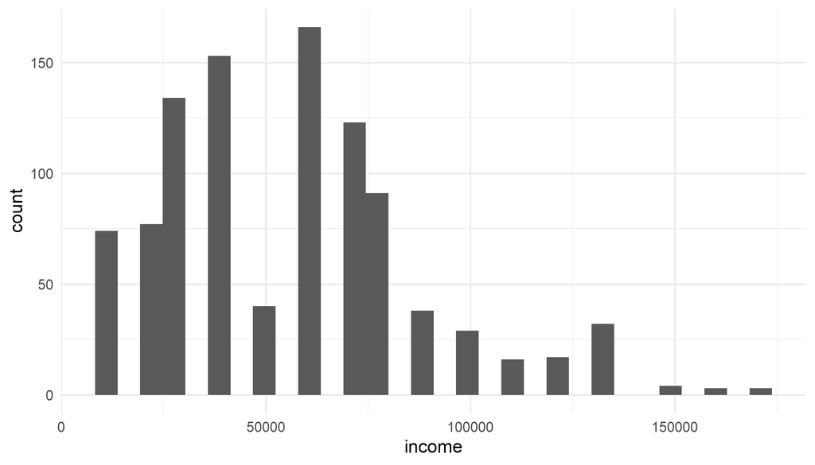

```r
#bikes %>% count(purchased_bike) #Balanced data

ggplot(bikes) +
  geom_histogram(aes(x = income)) #Histogram, x = income.
```

#### **Build Model**

##### Split data

```r
set.seed(234589) #Set a seed

#Split data into training (75%) and testing(25%)
bikes_split <- initial_split(bikes, strata = purchased_bike ,prop = 3/4)

#Extract training and testing sets
bikes_train <- training(bikes_split)
bikes_test <- testing(bikes_split)

#Create cross-validated version
bikes_cv <- vfold_cv(bikes_train, strata = purchased_bike)
```

##### Prepare recipe

```r
bikes_recipe <-
  recipe(purchased_bike ~., data = bikes_train) %>% #Set data and outcome
  step_corr(all_numeric()) %>% #Remove correlated variables
  step_dummy(all_nominal(), -all_outcomes()) %>% #Set dummy variables
  step_normalize(all_numeric()) #Scale and center data

bikes_train_preprocessed <-
  bikes_recipe %>%
  prep(bikes_train) %>%
  juice() #Finish the recipe and view the created data.
```

##### Specify model

```r
rf_model <-
  rand_forest() %>% #Random Forest Model
  set_args(mtry = tune(), min_n = tune(), trees = 1000) %>% #Arguments to tune
  set_mode("classification") %>% #Classification problem(not regression)
  set_engine("ranger") #Library ranger
```

##### Workflow

```r
rf_workflow <-
  workflow() %>%
  add_recipe(bikes_recipe) %>% #Add recipe
  add_model(rf_model) #Add model
```

##### Tune parameters

```r
rf_tune <-
  rf_workflow %>% #Model + data pre-processed
  tune_grid(resamples = bikes_cv, #Cross-validated object
            grid = 9) #grid = number of candidate models that have different values of mtry and min_n
```

##### Finalize workflow

Different metrics according to mtry and min_n.

```r
rf_tune %>%
  collect_metrics() #View values of accuracy and roc_auc
```

```
## # A tibble: 18 x 8
##     mtry min_n .metric  .estimator  mean     n std_err .config
##    <int> <int> <chr>    <chr>      <dbl> <int>   <dbl> <chr>
##  1    15    31 accuracy binary     0.698    10  0.0195 Preprocessor1_Model1
##  2    15    31 roc_auc  binary     0.757    10  0.0167 Preprocessor1_Model1
##  3     2    39 accuracy binary     0.668    10  0.0183 Preprocessor1_Model2
##  4     2    39 roc_auc  binary     0.744    10  0.0229 Preprocessor1_Model2
##  5     5    19 accuracy binary     0.702    10  0.0209 Preprocessor1_Model3
##  6     5    19 roc_auc  binary     0.769    10  0.0189 Preprocessor1_Model3
##  7     9     4 accuracy binary     0.712    10  0.0170 Preprocessor1_Model4
##  8     9     4 roc_auc  binary     0.776    10  0.0146 Preprocessor1_Model4
##  9    20    15 accuracy binary     0.687    10  0.0186 Preprocessor1_Model5
## 10    20    15 roc_auc  binary     0.762    10  0.0143 Preprocessor1_Model5
## 11    11    34 accuracy binary     0.700    10  0.0190 Preprocessor1_Model6
## 12    11    34 roc_auc  binary     0.758    10  0.0179 Preprocessor1_Model6
## 13    17    26 accuracy binary     0.699    10  0.0212 Preprocessor1_Model7
## 14    17    26 roc_auc  binary     0.759    10  0.0171 Preprocessor1_Model7
## 15    13    12 accuracy binary     0.703    10  0.0163 Preprocessor1_Model8
## 16    13    12 roc_auc  binary     0.769    10  0.0151 Preprocessor1_Model8
## 17     7     6 accuracy binary     0.707    10  0.0169 Preprocessor1_Model9
## 18     7     6 roc_auc  binary     0.776    10  0.0151 Preprocessor1_Model9
```

New and final model with the best tuned values.

```r
param_final <-
  rf_tune %>%
  select_best(metric = "roc_auc") #Select the best roc_auc

final_rf <-
  rf_model %>%
  finalize_model(param_final) #Finalize model with the best tuned values.
final_rf
```

```
## Random Forest Model Specification (classification)
##
## Main Arguments:
##   mtry = 7
##   trees = 1000
##   min_n = 6
##
## Computational engine: ranger
```

##### Variable importance

It seems that the top 3 most important features are: - Age - Number of cars - Number of children These 3 variables had the most impact on explaining the purchased bikes classification.

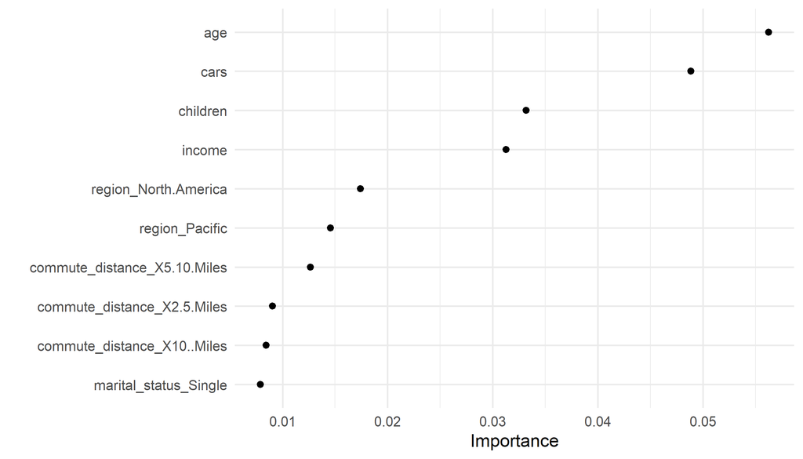

```r
final_rf %>%
  set_engine("ranger", importance = "permutation") %>% #Permutation method
  fit(purchased_bike ~., data = bikes_train_preprocessed) %>%
  vip(geom = "point") #Plot that shows the importance of the variables
```

##### Evaluate model

```r
final_workflow <-
  workflow() %>%
  add_recipe(bikes_recipe) %>% #Same recipe
  add_model(final_rf) #New model with the best values

#Now that tuning is done, use last_fit
#This function fits the final best model to the training set and evaluate the test set
final_res <-
  final_workflow %>%
    last_fit(bikes_split) #Split object

final_res %>%
  collect_metrics() #The metrics that collected are from the test set
```

```
## # A tibble: 2 x 4
##   .metric  .estimator .estimate .config
##   <chr>    <chr>          <dbl> <chr>
## 1 accuracy binary         0.659 Preprocessor1_Model1
## 2 roc_auc  binary         0.780 Preprocessor1_Model1
```

In here are classified the observations: correct-incorrect.

```r
test_predictions <-
  final_res %>%
    collect_predictions() %>%
    mutate(correct = case_when(purchased_bike == .pred_class ~ "Correct",
                               TRUE ~ "Incorrect")) #New column
test_predictions #Predictions on the test set
```

```
## # A tibble: 249 x 8
##    id      .pred_No .pred_Yes  .row .pred_class purchased_bike .config   correct
##    <chr>      <dbl>     <dbl> <int> <fct>       <fct>          <chr>     <chr>
##  1 train/~    0.487     0.513     2 Yes         No             Preproce~ Incorr~
##  2 train/~    0.249     0.751     8 Yes         Yes            Preproce~ Correct
##  3 train/~    0.612     0.388    13 No          No             Preproce~ Correct
##  4 train/~    0.358     0.642    15 Yes         Yes            Preproce~ Correct
##  5 train/~    0.629     0.371    20 No          Yes            Preproce~ Incorr~
##  6 train/~    0.470     0.530    28 Yes         No             Preproce~ Incorr~
##  7 train/~    0.710     0.290    35 No          Yes            Preproce~ Incorr~
##  8 train/~    0.899     0.101    39 No          No             Preproce~ Correct
##  9 train/~    0.582     0.418    40 No          Yes            Preproce~ Incorr~
## 10 train/~    0.802     0.198    46 No          Yes            Preproce~ Incorr~
## # ... with 239 more rows
```

Confusion matrix on testing data, another way to evaluate the model.

```r
test_predictions %>%
  conf_mat(truth = purchased_bike, estimate = .pred_class) #Confusion matrix on testing data
```

```
##           Truth
## Prediction No Yes
##        No  91  47
##        Yes 38  73
```

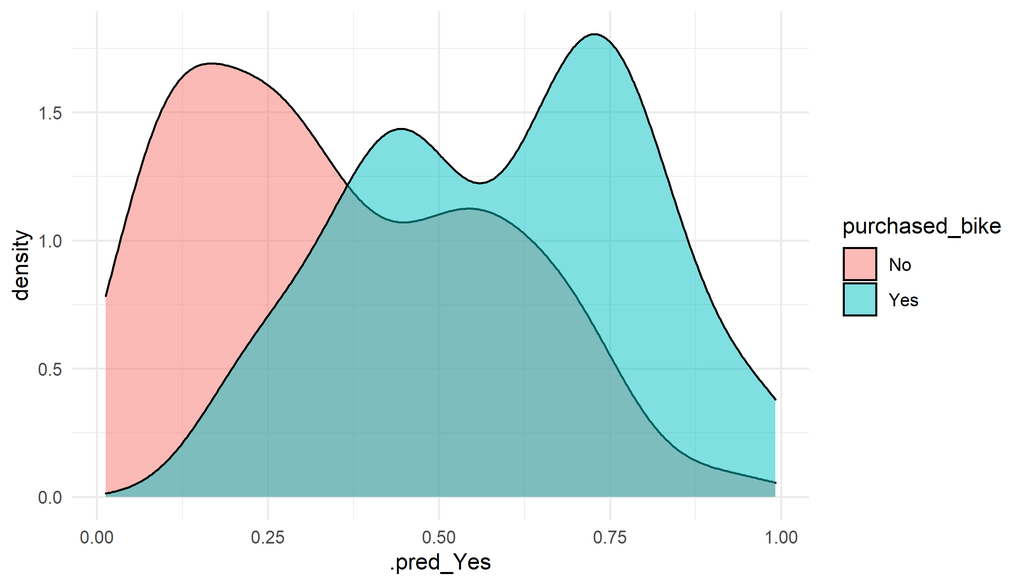

```r
test_predictions %>%
  ggplot() +
  geom_density(aes(x = .pred_Yes, fill = purchased_bike),
               alpha = 0.5)
```

##### Use model with new values

```r
final_model <- fit(rf_workflow, bikes)

#names(bikes)
new_bikes_data <-
  tribble(~marital_status, ~gender, ~income, ~children, ~education,
          ~occupation, ~home_owner, ~cars, ~commute_distance,
          ~region, ~age,
          "Single", "Male", 45000, 0, "Bachelors", "Professional","No",
          1,"5-10 Miles", "Pacific", 22) #Generate new data
new_bikes_data
```

```
## # A tibble: 1 x 11
##   marital_status gender income children education occupation   home_owner  cars
##   <chr>          <chr>   <dbl>    <dbl> <chr>     <chr>        <chr>      <dbl>
## 1 Single         Male    45000        0 Bachelors Professional No             1
## # ... with 3 more variables: commute_distance <chr>, region <chr>, age <dbl>
```

With this function we can predict new values, in order to classify future buyers, according to the same variables.

```r
predict(final_model, new_data = new_bikes_data) #Predictions with new data
```

```
## # A tibble: 1 x 1
##   .pred_class
##   <fct>
## 1 No
```

With more data and an improvement in computational power, we could improve the model’s metrics. Also, we could try other models and compare them to each other. Tidymodels are an excellent, flexible and ideal approach to study these type of problems.